# Risk Factor Analysis

## Outcome Variable

**Outcome Variable:** stunted

## Predictor Variables

**Intervention Variable:** nchldlt5

**Adjustment Set:**

- arm
- W_mage
- meducyrs
- feducyrs
- hhwealth_quart
- hfoodsec
- W_mhtcm
- W_mwtkg
- W_mbmi
- W_nrooms
- W_parity
- impfloor
- impsan
- safeh20
- delta_W_mage
- delta_meducyrs
- delta_feducyrs
- delta_hhwealth_quart
- delta_hfoodsec
- delta_W_mhtcm
- delta_W_mwtkg
- delta_W_mbmi
- delta_W_nrooms
- delta_W_parity
- delta_impfloor
- delta_impsan
- delta_safeh20

## Stratifying Variables

The analysis was stratified on these variable(s):

- agecat
- studyid
- country

## Data Summary

| agecat | studyid | country | nchldlt5 | stunted | n_cell | n |
| --- | --- | --- | --- | --- | --- | --- |
| Birth | IRC | INDIA | 1 | 0 | 72 | 388 |
| Birth | IRC | INDIA | 1 | 1 | 12 | 388 |
| Birth | IRC | INDIA | 2+ | 0 | 271 | 388 |
| Birth | IRC | INDIA | 2+ | 1 | 33 | 388 |
| Birth | JiVitA-3 | BANGLADESH | 1 | 0 | 9011 | 22431 |
| Birth | JiVitA-3 | BANGLADESH | 1 | 1 | 4975 | 22431 |
| Birth | JiVitA-3 | BANGLADESH | 2+ | 0 | 6039 | 22431 |
| Birth | JiVitA-3 | BANGLADESH | 2+ | 1 | 2406 | 22431 |
| Birth | NIH-Crypto | BANGLADESH | 1 | 0 | 449 | 732 |
| Birth | NIH-Crypto | BANGLADESH | 1 | 1 | 73 | 732 |
| Birth | NIH-Crypto | BANGLADESH | 2+ | 0 | 182 | 732 |
| Birth | NIH-Crypto | BANGLADESH | 2+ | 1 | 28 | 732 |
| Birth | PROVIDE | BANGLADESH | 1 | 0 | 354 | 539 |
| Birth | PROVIDE | BANGLADESH | 1 | 1 | 37 | 539 |
| Birth | PROVIDE | BANGLADESH | 2+ | 0 | 137 | 539 |
| Birth | PROVIDE | BANGLADESH | 2+ | 1 | 11 | 539 |
| 6 months | IRC | INDIA | 1 | 0 | 67 | 407 |
| 6 months | IRC | INDIA | 1 | 1 | 22 | 407 |
| 6 months | IRC | INDIA | 2+ | 0 | 240 | 407 |
| 6 months | IRC | INDIA | 2+ | 1 | 78 | 407 |
| 6 months | JiVitA-3 | BANGLADESH | 1 | 0 | 8093 | 16800 |
| 6 months | JiVitA-3 | BANGLADESH | 1 | 1 | 2794 | 16800 |
| 6 months | JiVitA-3 | BANGLADESH | 2+ | 0 | 4484 | 16800 |
| 6 months | JiVitA-3 | BANGLADESH | 2+ | 1 | 1429 | 16800 |
| 6 months | LCNI-5 | MALAWI | 1 | 0 | 263 | 811 |
| 6 months | LCNI-5 | MALAWI | 1 | 1 | 127 | 811 |
| 6 months | LCNI-5 | MALAWI | 2+ | 0 | 253 | 811 |
| 6 months | LCNI-5 | MALAWI | 2+ | 1 | 168 | 811 |
| 6 months | NIH-Crypto | BANGLADESH | 1 | 0 | 400 | 715 |
| 6 months | NIH-Crypto | BANGLADESH | 1 | 1 | 107 | 715 |
| 6 months | NIH-Crypto | BANGLADESH | 2+ | 0 | 165 | 715 |
| 6 months | NIH-Crypto | BANGLADESH | 2+ | 1 | 43 | 715 |
| 6 months | PROVIDE | BANGLADESH | 1 | 0 | 368 | 604 |
| 6 months | PROVIDE | BANGLADESH | 1 | 1 | 70 | 604 |
| 6 months | PROVIDE | BANGLADESH | 2+ | 0 | 140 | 604 |
| 6 months | PROVIDE | BANGLADESH | 2+ | 1 | 26 | 604 |
| 6 months | TanzaniaChild2 | TANZANIA, UNITED REPUBLIC OF | 1 | 0 | 1267 | 2020 |
| 6 months | TanzaniaChild2 | TANZANIA, UNITED REPUBLIC OF | 1 | 1 | 124 | 2020 |
| 6 months | TanzaniaChild2 | TANZANIA, UNITED REPUBLIC OF | 2+ | 0 | 558 | 2020 |
| 6 months | TanzaniaChild2 | TANZANIA, UNITED REPUBLIC OF | 2+ | 1 | 71 | 2020 |
| 24 months | IRC | INDIA | 1 | 0 | 58 | 409 |
| 24 months | IRC | INDIA | 1 | 1 | 31 | 409 |
| 24 months | IRC | INDIA | 2+ | 0 | 179 | 409 |
| 24 months | IRC | INDIA | 2+ | 1 | 141 | 409 |
| 24 months | JiVitA-3 | BANGLADESH | 1 | 0 | 2889 | 8622 |
| 24 months | JiVitA-3 | BANGLADESH | 1 | 1 | 2565 | 8622 |
| 24 months | JiVitA-3 | BANGLADESH | 2+ | 0 | 1499 | 8622 |
| 24 months | JiVitA-3 | BANGLADESH | 2+ | 1 | 1669 | 8622 |
| 24 months | LCNI-5 | MALAWI | 1 | 0 | 161 | 571 |
| 24 months | LCNI-5 | MALAWI | 1 | 1 | 122 | 571 |
| 24 months | LCNI-5 | MALAWI | 2+ | 0 | 158 | 571 |
| 24 months | LCNI-5 | MALAWI | 2+ | 1 | 130 | 571 |
| 24 months | NIH-Crypto | BANGLADESH | 1 | 0 | 276 | 514 |
| 24 months | NIH-Crypto | BANGLADESH | 1 | 1 | 81 | 514 |
| 24 months | NIH-Crypto | BANGLADESH | 2+ | 0 | 106 | 514 |
| 24 months | NIH-Crypto | BANGLADESH | 2+ | 1 | 51 | 514 |
| 24 months | PROVIDE | BANGLADESH | 1 | 0 | 299 | 578 |
| 24 months | PROVIDE | BANGLADESH | 1 | 1 | 125 | 578 |
| 24 months | PROVIDE | BANGLADESH | 2+ | 0 | 89 | 578 |
| 24 months | PROVIDE | BANGLADESH | 2+ | 1 | 65 | 578 |
| 24 months | TanzaniaChild2 | TANZANIA, UNITED REPUBLIC OF | 1 | 0 | 4 | 6 |
| 24 months | TanzaniaChild2 | TANZANIA, UNITED REPUBLIC OF | 1 | 1 | 1 | 6 |
| 24 months | TanzaniaChild2 | TANZANIA, UNITED REPUBLIC OF | 2+ | 0 | 1 | 6 |
| 24 months | TanzaniaChild2 | TANZANIA, UNITED REPUBLIC OF | 2+ | 1 | 0 | 6 |

The following strata were considered:

- agecat: 24 months, studyid: IRC, country: INDIA
- agecat: 24 months, studyid: JiVitA-3, country: BANGLADESH
- agecat: 24 months, studyid: LCNI-5, country: MALAWI
- agecat: 24 months, studyid: NIH-Crypto, country: BANGLADESH
- agecat: 24 months, studyid: PROVIDE, country: BANGLADESH
- agecat: 24 months, studyid: TanzaniaChild2, country: TANZANIA, UNITED REPUBLIC OF
- agecat: 6 months, studyid: IRC, country: INDIA
- agecat: 6 months, studyid: JiVitA-3, country: BANGLADESH
- agecat: 6 months, studyid: LCNI-5, country: MALAWI
- agecat: 6 months, studyid: NIH-Crypto, country: BANGLADESH
- agecat: 6 months, studyid: PROVIDE, country: BANGLADESH
- agecat: 6 months, studyid: TanzaniaChild2, country: TANZANIA, UNITED REPUBLIC OF
- agecat: Birth, studyid: IRC, country: INDIA
- agecat: Birth, studyid: JiVitA-3, country: BANGLADESH
- agecat: Birth, studyid: NIH-Crypto, country: BANGLADESH
- agecat: Birth, studyid: PROVIDE, country: BANGLADESH

### Dropped Strata

Some strata were dropped due to rare outcomes:

- agecat: 24 months, studyid: TanzaniaChild2, country: TANZANIA, UNITED REPUBLIC OF

## Methods Detail

We’re interested in the causal parameters $E[Y_a]$ for all values of $a \in \mathcal{A}$. These parameters represent the mean outcome if, possibly contrary to fact, we intervened to set all units to have $A=a$. Under the randomization and positivity assumptions, these are identified by the statistical parameters $\psi_a=E_W[E_{Y|A,W}(Y|A=a,W)]$. In addition, we’re interested in the mean of $Y$, $E[Y]$ under no intervention (the observed mean). We will estimate these parameters by using SuperLearner to fit the relevant likelihood factors – $E_{Y|A,W}(Y|A=a,W)$ and $p(A=a|W)$, and then updating our likelihood fit using a joint TMLE.

For unadjusted analyses ($W=\{\}$), initial likelihoods were estimated using Lrnr_glm to estimate the simple $E(Y|A)$ and Lrnr_mean to estimate $p(A)$. For adjusted analyses, a small library containing Lrnr_glmnet, Lrnr_xgboost, and Lrnr_mean was used.

Having estimated these parameters, we will then use the delta method to estimate relative risks and attributable risks relative to a prespecified baseline level of $A$.

# Results Detail

## Results Plots

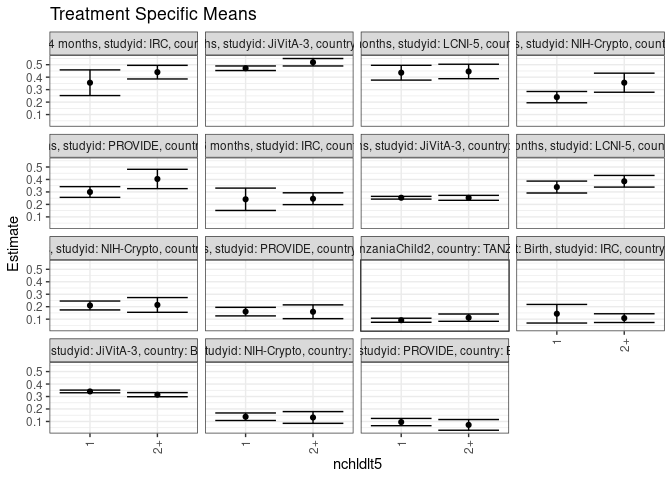

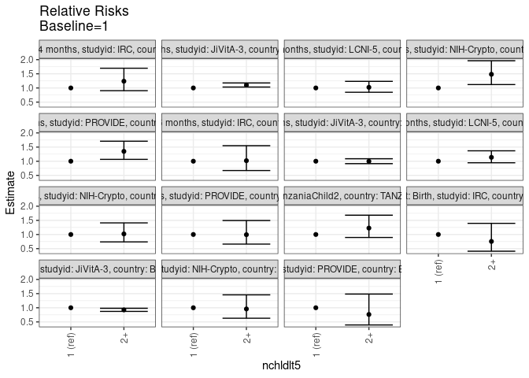

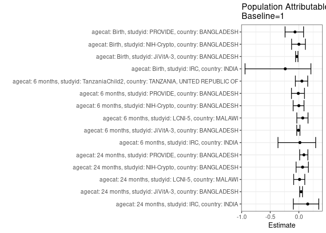

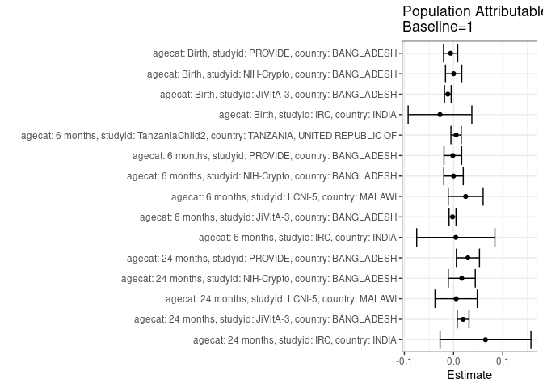

## Results Table

### Parameter: TSM

| agecat | studyid | country | intervention_level | baseline_level | estimate | ci_lower | ci_upper |
| --- | --- | --- | --- | --- | --- | --- | --- |
| Birth | IRC | INDIA | 1 | NA | 0.1435317 | 0.0688767 | 0.2181867 |
| Birth | IRC | INDIA | 2+ | NA | 0.1083745 | 0.0734137 | 0.1433352 |
| Birth | JiVitA-3 | BANGLADESH | 1 | NA | 0.3406775 | 0.3299918 | 0.3513632 |
| Birth | JiVitA-3 | BANGLADESH | 2+ | NA | 0.3149418 | 0.2983568 | 0.3315268 |
| Birth | NIH-Crypto | BANGLADESH | 1 | NA | 0.1378280 | 0.1076212 | 0.1680349 |
| Birth | NIH-Crypto | BANGLADESH | 2+ | NA | 0.1320028 | 0.0848595 | 0.1791461 |
| Birth | PROVIDE | BANGLADESH | 1 | NA | 0.0950235 | 0.0659395 | 0.1241075 |
| Birth | PROVIDE | BANGLADESH | 2+ | NA | 0.0725119 | 0.0296747 | 0.1153490 |
| 6 months | IRC | INDIA | 1 | NA | 0.2411323 | 0.1514459 | 0.3308187 |
| 6 months | IRC | INDIA | 2+ | NA | 0.2456701 | 0.1982201 | 0.2931200 |
| 6 months | JiVitA-3 | BANGLADESH | 1 | NA | 0.2534531 | 0.2424926 | 0.2644136 |
| 6 months | JiVitA-3 | BANGLADESH | 2+ | NA | 0.2527057 | 0.2329234 | 0.2724879 |
| 6 months | LCNI-5 | MALAWI | 1 | NA | 0.3391470 | 0.2914836 | 0.3868105 |
| 6 months | LCNI-5 | MALAWI | 2+ | NA | 0.3856357 | 0.3387357 | 0.4325357 |
| 6 months | NIH-Crypto | BANGLADESH | 1 | NA | 0.2098419 | 0.1740961 | 0.2455876 |
| 6 months | NIH-Crypto | BANGLADESH | 2+ | NA | 0.2141047 | 0.1550854 | 0.2731240 |
| 6 months | PROVIDE | BANGLADESH | 1 | NA | 0.1604379 | 0.1260336 | 0.1948421 |
| 6 months | PROVIDE | BANGLADESH | 2+ | NA | 0.1593313 | 0.1039379 | 0.2147246 |
| 6 months | TanzaniaChild2 | TANZANIA, UNITED REPUBLIC OF | 1 | NA | 0.0913991 | 0.0751720 | 0.1076263 |
| 6 months | TanzaniaChild2 | TANZANIA, UNITED REPUBLIC OF | 2+ | NA | 0.1120542 | 0.0827337 | 0.1413747 |
| 24 months | IRC | INDIA | 1 | NA | 0.3556319 | 0.2526532 | 0.4586106 |
| 24 months | IRC | INDIA | 2+ | NA | 0.4403899 | 0.3857755 | 0.4950043 |
| 24 months | JiVitA-3 | BANGLADESH | 1 | NA | 0.4716528 | 0.4533208 | 0.4899849 |
| 24 months | JiVitA-3 | BANGLADESH | 2+ | NA | 0.5197077 | 0.4898869 | 0.5495284 |
| 24 months | LCNI-5 | MALAWI | 1 | NA | 0.4361086 | 0.3767687 | 0.4954486 |
| 24 months | LCNI-5 | MALAWI | 2+ | NA | 0.4459922 | 0.3879662 | 0.5040182 |
| 24 months | NIH-Crypto | BANGLADESH | 1 | NA | 0.2400919 | 0.1948801 | 0.2853037 |
| 24 months | NIH-Crypto | BANGLADESH | 2+ | NA | 0.3558233 | 0.2792790 | 0.4323676 |
| 24 months | PROVIDE | BANGLADESH | 1 | NA | 0.2995296 | 0.2563508 | 0.3427085 |
| 24 months | PROVIDE | BANGLADESH | 2+ | NA | 0.4040008 | 0.3265629 | 0.4814387 |

### Parameter: E(Y)

| agecat | studyid | country | intervention_level | baseline_level | estimate | ci_lower | ci_upper |
| --- | --- | --- | --- | --- | --- | --- | --- |
| Birth | IRC | INDIA | NA | NA | 0.1159794 | 0.0840777 | 0.1478811 |
| Birth | JiVitA-3 | BANGLADESH | NA | NA | 0.3290535 | 0.3216788 | 0.3364283 |
| Birth | NIH-Crypto | BANGLADESH | NA | NA | 0.1379781 | 0.1129774 | 0.1629789 |
| Birth | PROVIDE | BANGLADESH | NA | NA | 0.0890538 | 0.0649864 | 0.1131212 |
| 6 months | IRC | INDIA | NA | NA | 0.2457002 | 0.2038248 | 0.2875757 |
| 6 months | JiVitA-3 | BANGLADESH | NA | NA | 0.2513690 | 0.2432434 | 0.2594947 |
| 6 months | LCNI-5 | MALAWI | NA | NA | 0.3637485 | 0.3306185 | 0.3968784 |
| 6 months | NIH-Crypto | BANGLADESH | NA | NA | 0.2097902 | 0.1799252 | 0.2396552 |
| 6 months | PROVIDE | BANGLADESH | NA | NA | 0.1589404 | 0.1297581 | 0.1881227 |
| 6 months | TanzaniaChild2 | TANZANIA, UNITED REPUBLIC OF | NA | NA | 0.0965347 | 0.0836528 | 0.1094165 |
| 24 months | IRC | INDIA | NA | NA | 0.4205379 | 0.3726382 | 0.4684376 |
| 24 months | JiVitA-3 | BANGLADESH | NA | NA | 0.4910694 | 0.4779621 | 0.5041766 |
| 24 months | LCNI-5 | MALAWI | NA | NA | 0.4413310 | 0.4005676 | 0.4820944 |
| 24 months | NIH-Crypto | BANGLADESH | NA | NA | 0.2568093 | 0.2190047 | 0.2946140 |
| 24 months | PROVIDE | BANGLADESH | NA | NA | 0.3287197 | 0.2903909 | 0.3670485 |

### Parameter: RR

| agecat | studyid | country | intervention_level | baseline_level | estimate | ci_lower | ci_upper |
| --- | --- | --- | --- | --- | --- | --- | --- |
| Birth | IRC | INDIA | 1 | 1 | 1.0000000 | 1.0000000 | 1.0000000 |
| Birth | IRC | INDIA | 2+ | 1 | 0.7550560 | 0.4091807 | 1.3932953 |
| Birth | JiVitA-3 | BANGLADESH | 1 | 1 | 1.0000000 | 1.0000000 | 1.0000000 |
| Birth | JiVitA-3 | BANGLADESH | 2+ | 1 | 0.9244573 | 0.8708982 | 0.9813103 |
| Birth | NIH-Crypto | BANGLADESH | 1 | 1 | 1.0000000 | 1.0000000 | 1.0000000 |
| Birth | NIH-Crypto | BANGLADESH | 2+ | 1 | 0.9577354 | 0.6297592 | 1.4565201 |
| Birth | PROVIDE | BANGLADESH | 1 | 1 | 1.0000000 | 1.0000000 | 1.0000000 |
| Birth | PROVIDE | BANGLADESH | 2+ | 1 | 0.7630941 | 0.3923761 | 1.4840672 |
| 6 months | IRC | INDIA | 1 | 1 | 1.0000000 | 1.0000000 | 1.0000000 |
| 6 months | IRC | INDIA | 2+ | 1 | 1.0188187 | 0.6701549 | 1.5488828 |
| 6 months | JiVitA-3 | BANGLADESH | 1 | 1 | 1.0000000 | 1.0000000 | 1.0000000 |
| 6 months | JiVitA-3 | BANGLADESH | 2+ | 1 | 0.9970511 | 0.9146356 | 1.0868928 |
| 6 months | LCNI-5 | MALAWI | 1 | 1 | 1.0000000 | 1.0000000 | 1.0000000 |
| 6 months | LCNI-5 | MALAWI | 2+ | 1 | 1.1370753 | 0.9454287 | 1.3675703 |
| 6 months | NIH-Crypto | BANGLADESH | 1 | 1 | 1.0000000 | 1.0000000 | 1.0000000 |
| 6 months | NIH-Crypto | BANGLADESH | 2+ | 1 | 1.0203143 | 0.7386671 | 1.4093511 |
| 6 months | PROVIDE | BANGLADESH | 1 | 1 | 1.0000000 | 1.0000000 | 1.0000000 |
| 6 months | PROVIDE | BANGLADESH | 2+ | 1 | 0.9931026 | 0.6599832 | 1.4943606 |
| 6 months | TanzaniaChild2 | TANZANIA, UNITED REPUBLIC OF | 1 | 1 | 1.0000000 | 1.0000000 | 1.0000000 |
| 6 months | TanzaniaChild2 | TANZANIA, UNITED REPUBLIC OF | 2+ | 1 | 1.2259874 | 0.8938862 | 1.6814725 |
| 24 months | IRC | INDIA | 1 | 1 | 1.0000000 | 1.0000000 | 1.0000000 |
| 24 months | IRC | INDIA | 2+ | 1 | 1.2383307 | 0.9036011 | 1.6970574 |
| 24 months | JiVitA-3 | BANGLADESH | 1 | 1 | 1.0000000 | 1.0000000 | 1.0000000 |
| 24 months | JiVitA-3 | BANGLADESH | 2+ | 1 | 1.1018860 | 1.0318888 | 1.1766315 |
| 24 months | LCNI-5 | MALAWI | 1 | 1 | 1.0000000 | 1.0000000 | 1.0000000 |
| 24 months | LCNI-5 | MALAWI | 2+ | 1 | 1.0226630 | 0.8480718 | 1.2331971 |
| 24 months | NIH-Crypto | BANGLADESH | 1 | 1 | 1.0000000 | 1.0000000 | 1.0000000 |
| 24 months | NIH-Crypto | BANGLADESH | 2+ | 1 | 1.4820294 | 1.1198947 | 1.9612659 |
| 24 months | PROVIDE | BANGLADESH | 1 | 1 | 1.0000000 | 1.0000000 | 1.0000000 |
| 24 months | PROVIDE | BANGLADESH | 2+ | 1 | 1.3487840 | 1.0653798 | 1.7075772 |

### Parameter: PAR

| agecat | studyid | country | intervention_level | baseline_level | estimate | ci_lower | ci_upper |
| --- | --- | --- | --- | --- | --- | --- | --- |
| Birth | IRC | INDIA | 1 | NA | -0.0275523 | -0.0922942 | 0.0371896 |
| Birth | JiVitA-3 | BANGLADESH | 1 | NA | -0.0116239 | -0.0184306 | -0.0048172 |
| Birth | NIH-Crypto | BANGLADESH | 1 | NA | 0.0001501 | -0.0163898 | 0.0166900 |
| Birth | PROVIDE | BANGLADESH | 1 | NA | -0.0059697 | -0.0203574 | 0.0084181 |
| 6 months | IRC | INDIA | 1 | NA | 0.0045680 | -0.0748857 | 0.0840216 |
| 6 months | JiVitA-3 | BANGLADESH | 1 | NA | -0.0020840 | -0.0091407 | 0.0049726 |
| 6 months | LCNI-5 | MALAWI | 1 | NA | 0.0246014 | -0.0108449 | 0.0600478 |
| 6 months | NIH-Crypto | BANGLADESH | 1 | NA | -0.0000517 | -0.0198379 | 0.0197345 |
| 6 months | PROVIDE | BANGLADESH | 1 | NA | -0.0014975 | -0.0194660 | 0.0164711 |
| 6 months | TanzaniaChild2 | TANZANIA, UNITED REPUBLIC OF | 1 | NA | 0.0051355 | -0.0053316 | 0.0156027 |
| 24 months | IRC | INDIA | 1 | NA | 0.0649060 | -0.0274823 | 0.1572943 |
| 24 months | JiVitA-3 | BANGLADESH | 1 | NA | 0.0194165 | 0.0073976 | 0.0314354 |
| 24 months | LCNI-5 | MALAWI | 1 | NA | 0.0052224 | -0.0376702 | 0.0481149 |
| 24 months | NIH-Crypto | BANGLADESH | 1 | NA | 0.0167174 | -0.0107190 | 0.0441538 |
| 24 months | PROVIDE | BANGLADESH | 1 | NA | 0.0291901 | 0.0057080 | 0.0526722 |

### Parameter: PAF

| agecat | studyid | country | intervention_level | baseline_level | estimate | ci_lower | ci_upper |
| --- | --- | --- | --- | --- | --- | --- | --- |
| Birth | IRC | INDIA | 1 | NA | -0.2375622 | -0.9399070 | 0.2104981 |
| Birth | JiVitA-3 | BANGLADESH | 1 | NA | -0.0353253 | -0.0561260 | -0.0149344 |
| Birth | NIH-Crypto | BANGLADESH | 1 | NA | 0.0010878 | -0.1262786 | 0.1140509 |
| Birth | PROVIDE | BANGLADESH | 1 | NA | -0.0670346 | -0.2408356 | 0.0824224 |
| 6 months | IRC | INDIA | 1 | NA | 0.0185916 | -0.3644349 | 0.2940943 |
| 6 months | JiVitA-3 | BANGLADESH | 1 | NA | -0.0082908 | -0.0367489 | 0.0193862 |
| 6 months | LCNI-5 | MALAWI | 1 | NA | 0.0676331 | -0.0350656 | 0.1601420 |
| 6 months | NIH-Crypto | BANGLADESH | 1 | NA | -0.0002463 | -0.0991503 | 0.0897581 |
| 6 months | PROVIDE | BANGLADESH | 1 | NA | -0.0094216 | -0.1290454 | 0.0975280 |
| 6 months | TanzaniaChild2 | TANZANIA, UNITED REPUBLIC OF | 1 | NA | 0.0531987 | -0.0615839 | 0.1555705 |
| 24 months | IRC | INDIA | 1 | NA | 0.1543404 | -0.0968585 | 0.3480106 |
| 24 months | JiVitA-3 | BANGLADESH | 1 | NA | 0.0395393 | 0.0146585 | 0.0637918 |
| 24 months | LCNI-5 | MALAWI | 1 | NA | 0.0118332 | -0.0903096 | 0.1044070 |
| 24 months | NIH-Crypto | BANGLADESH | 1 | NA | 0.0650966 | -0.0478504 | 0.1658691 |
| 24 months | PROVIDE | BANGLADESH | 1 | NA | 0.0887993 | 0.0146491 | 0.1573694 |